# Build an unsupervised segmentation model to classify the Yoga poses 107 dataset - https://www.kaggle.com/datasets/arrowe/yoga-poses-dataset-107

# Train the model with the training and validation data

# After each epoch, the model is evaluated on the val_images_normalized and val_labels_categorical data to monitor its performance on unseen data.

During each epoch, after the model processes a batch of data, it makes predictions. These predictions are compared to the true labels to compute the accuracy for that batch. The **training accuracy for the epoch is the average accuracy over all the batches in the training dataset**.

After each epoch, the **model makes predictions on the entire validation dataset, and these predictions are compared to the true labels to compute the validation accuracy for the epoch**.

```python
history = model.fit(train_images_normalized, train_labels_categorical, validation_data=(val_images_normalized, val_labels_categorical), epochs=100, batch_size=32, callbacks=callbacks)
```

# Plot the training and validation accuracy and loss

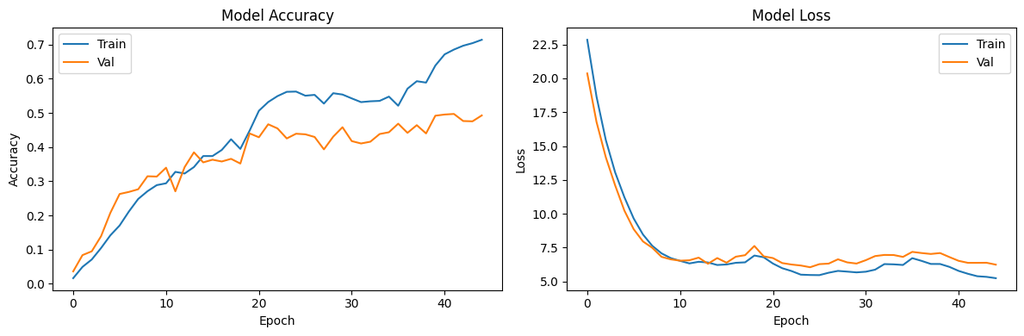

```python
import matplotlib.pyplot as plt

# Plot training & validation accuracy
plt.figure(figsize=(12, 4))
plt.subplot(1, 2, 1)
plt.plot(history.history['accuracy'], label='Train')
plt.plot(history.history['val_accuracy'], label='Val')
plt.title('Model Accuracy')
plt.xlabel('Epoch')
plt.ylabel('Accuracy')
plt.legend(loc='best')

# Plot training & validation loss
plt.subplot(1, 2, 2)
plt.plot(history.history['loss'], label='Train')
plt.plot(history.history['val_loss'], label='Val')
plt.title('Model Loss')
plt.xlabel('Epoch')
plt.ylabel('Loss')
plt.legend(loc='best')

plt.tight_layout()
plt.show()
```

```python
model.summary()
```

```
Model: "sequential"
_________________________________________________________________
 Layer (type)                Output Shape              Param #
=================================================================
 conv2d (Conv2D)             (None, 222, 222, 64)      1792

 batch_normalization (Batch  (None, 222, 222, 64)      256
 Normalization)

 max_pooling2d (MaxPooling2  (None, 111, 111, 64)      0
 D)

 conv2d_1 (Conv2D)           (None, 109, 109, 128)     73856

 batch_normalization_1 (Bat  (None, 109, 109, 128)     512
 chNormalization)

 max_pooling2d_1 (MaxPoolin  (None, 54, 54, 128)       0
 g2D)

 conv2d_2 (Conv2D)           (None, 52, 52, 256)       295168

 batch_normalization_2 (Bat  (None, 52, 52, 256)       1024
 chNormalization)

 max_pooling2d_2 (MaxPoolin  (None, 26, 26, 256)       0
 g2D)

 conv2d_3 (Conv2D)           (None, 24, 24, 512)       1180160

 batch_normalization_3 (Bat  (None, 24, 24, 512)       2048
 chNormalization)

 max_pooling2d_3 (MaxPoolin  (None, 12, 12, 512)       0
 g2D)

 flatten (Flatten)           (None, 73728)             0

 dense (Dense)               (None, 512)               37749248

 dropout (Dropout)           (None, 512)               0

 batch_normalization_4 (Bat  (None, 512)               2048
 chNormalization)

 dense_1 (Dense)             (None, 256)               131328

 dropout_1 (Dropout)         (None, 256)               0

 batch_normalization_5 (Bat  (None, 256)               1024
 chNormalization)

 dense_2 (Dense)             (None, 107)               27499

=================================================================
Total params: 39465963 (150.55 MB)
Trainable params: 39462507 (150.54 MB)
Non-trainable params: 3456 (13.50 KB)
_________________________________________________________________
```

# Remove the Top Layers and Extract Features

```python
from tensorflow.keras.models import Model

# Extract features using the trained CNN model without the top layers
def extract_features(model, data):
    # I want to remove the final classification layers and take features from the last convolutional or flattening layer,
    # as these provide rich feature representations.
    # For my model, the Flatten layer is a common choice for feature extraction as it flattens the 2D output from the convolutional layers into a 1D vector,
    # which can be directly used for clustering.
    feature_extractor = Model(inputs=model.input, outputs=model.get_layer('flatten').output)
    features = feature_extractor.predict(data)
    return features

# Extract features from the training, validation, and test datasets
train_features = extract_features(model, train_images_normalized)
val_features = extract_features(model, val_images_normalized)
test_features = extract_features(model, test_images_normalized)

print(f"Extracted features shape: {train_features.shape}")
```

```
Extracted features shape: (4150, 73728)
```

# Flatten the Feature Vectors

```python
# Flatten the feature vectors
train_features_flattened = train_features.reshape(train_features.shape[0], -1)
val_features_flattened = val_features.reshape(val_features.shape[0], -1)
test_features_flattened = test_features.reshape(test_features.shape[0], -1)

print(f"Flattened features shape: {train_features_flattened.shape}")
```

```
Flattened features shape: (4150, 73728)
```

# Apply Clustering Algorithms

```python
from sklearn.cluster import KMeans, DBSCAN
from sklearn.metrics import silhouette_score

# Apply K-means clustering
kmeans = KMeans(n_clusters=5, random_state=42)
kmeans_labels = kmeans.fit_predict(train_features_flattened)

# Apply DBSCAN clustering
dbscan = DBSCAN(eps=0.5, min_samples=5)
dbscan_labels = dbscan.fit_predict(train_features_flattened)

# Calculate Silhouette Score for K-means
silhouette_kmeans = silhouette_score(train_features_flattened, kmeans_labels)
print(f"Silhouette Score for K-means: {silhouette_kmeans}")

# Calculate Silhouette Score for DBSCAN
# Note: Silhouette Score for DBSCAN might not be valid if there are noise points (-1 labels)
dbscan_valid_labels = dbscan_labels[dbscan_labels != -1]
if len(dbscan_valid_labels) > 0:
    silhouette_dbscan = silhouette_score(train_features_flattened[dbscan_labels != -1], dbscan_valid_labels)
    print(f"Silhouette Score for DBSCAN: {silhouette_dbscan}")
else:
    print("DBSCAN resulted in too many noise points, Silhouette Score is not valid.")
```

```
Silhouette Score for K-means: 0.007870660163462162
DBSCAN resulted in too many noise points, Silhouette Score is not valid.
```

# Visual Inspection

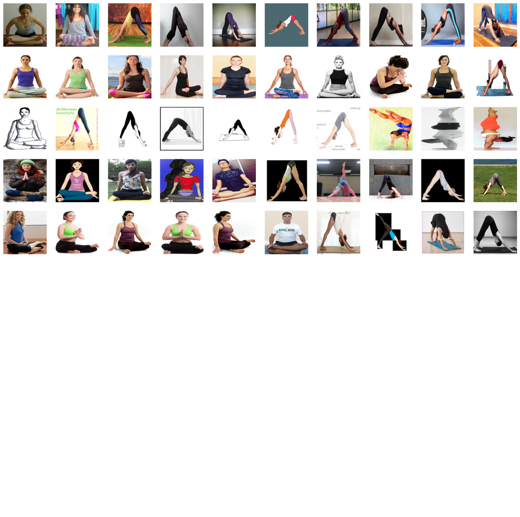

```python
import matplotlib.pyplot as plt
import numpy as np

# Visual inspection of clusters
# data: The dataset containing the images
# labels: The labels assigned to each image by the clustering algorithm
# num_clusters: The number of clusters to plot
def plot_clusters(data, labels, num_clusters=5):
    #  Create a grid of subplots with num_clusters rows and 10 columns, with each subplot having a size of 20x20 inches.
    fig, ax = plt.subplots(num_clusters, 10, figsize=(20, 20))
    for cluster in range(num_clusters):
        cluster_indices = np.where(labels == cluster)[0]
        for i in range(10):
            if i < len(cluster_indices):
                img = data[cluster_indices[i]].reshape(224, 224, 3)
                ax[cluster, i].imshow(img)
                ax[cluster, i].axis('off')
            else:
                ax[cluster, i].axis('off')
    plt.show()

# Plot K-means clusters
plot_clusters(train_images_normalized, kmeans_labels, num_clusters=10)

# Plot DBSCAN clusters (if applicable)
# Call the plot_clusters function to visualize the valid clusters formed by DBSCAN, excluding the noise points (points labeled as -1)
if len(dbscan_valid_labels) > 0:
    plot_clusters(train_images_normalized[dbscan_labels != -1], dbscan_valid_labels, num_clusters=10)
```

# The performance of unsupervised image segmentation by extracting features and then applyinng clustering algorithms is not ideal. Silhouette Score is very low.